# Reliability Growth

Ammar Al-Khaldi

2017-12-20

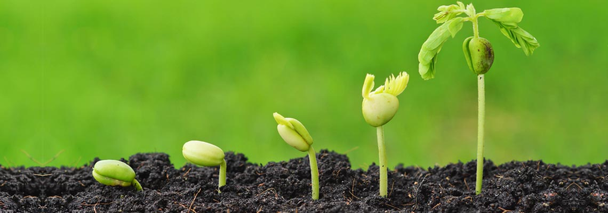

# What is the Reliability Growth?

## Background

The Reliability Growth Analysis (RGA) is an analytical tool used to assess the change in the reliability of equipment, system or a plant. The output of the analysis is given as:-

- Trend showing the reliability change in terms of time(cycle, Km, ) on the X-axis and failure rate (or MTBF since it’s the inverse of failure rate) on the Y-axis.

[interactive chart not shown]

- Parameter $\beta$ which can be interpreted as follow:-
  - $\beta > 1$: The system reliability is decreasing.
  - $\beta < 1$: The system reliability is increasing.
  - $\beta = 1$: The system reliability is remain constant.

in the previous plot the $\beta = 0.6142$

## How it differs from other reliability metrics?

### MTBF

The Mean Time Between Failure (MTBF) is a well-known reliability metric, It’s widely used despite the fact of lacking the ability to assess the change in the reliability, this is one of many issues faced while using the MTBF.

For further information about the MTBF issues [check this article.](https://www.linkedin.com/pulse/real-reliability-stop-abusing-ammar-alkhaldi-cbbss-/)

### Weibull

Weibull analysis is a parametric analysis that gives two parameters $\beta$ and $\eta$ so-called shape (slope) and scale (characteristic life) respectively. The Weibull analysis is a powerful reliability distribution used to model degradation process (e.g. fatigue, corrosion, abrasion, etc). and since it’s used to model failure mode this imply it’s weakness of modeling mixed failure modes not to mention a whole equipment or a system.

## when to use it?

This brings us to the usage of the RGA, which is used to assess a whole equipment or system. RGA is originally used to test the product reliability under design, after testing the first prototype the tester will check if the reliability meeting the requirement (using destructive testing or simulation) if not a modification will be done to improve the reliability and the test will take place again and the RGA is used to measure the improvement over time and to interpolate the future improvement (when and how many iterations to meet the target) this usually done in Accelerated Life Testing Analysis (ALTA) following the “IEC 61014 programmes for reliability growth”. This doesn’t mean that the RGA can’t be used in the utilization phase. The analogy with a running plant is the changes in the system, like MOCs and introduction of RCM program, which should be a point of time dividing the system life to before and after improvement.

## Different flavors

RGA is a slightly different mathematical way:-

- Duane
- Crow-AMSAA
- IEC 61164

# RGA for multiple systems

Performing RGA for all the RCM systems can be a logical step to evaluate how is our RCM effecting the failure rate and can tell in numbers if the RCM efforts succeed or not. we can use a simple equation like the one below as a start.
$$Reliability\; Growth\; Improved\; for\; completed\; RCM\; systems \over Total\; No\; of\; completed\; RCM\; systems$$
So the KPI require you to:-

1. Perform RGA for all the RGA system
2. Check how many of these RGAs returned $\beta < 1$
3. Divide the sum of RGAs with $\beta < 1$ over the total number of RCM systems. So for a company with 150 RCM systems you need to perform 150 RGAs. which sound silly and hideous, but don’t worry there is a workaround.

## The challenge of multiple systems

While analyzing the reliability of a single system sound to be a tough task (if we do it in the right way) analyzing more than 100 systems sound to be crazy. but in the age of data science and big data, this seems to be a perfect opportunity for [automation of knowledge work](https://www.mckinsey.com/business-functions/digital-mckinsey/our-insights/disruptive-technologies) and use of dormant data. before we proceed you need to know in advance that you must have a programming background or the ability to learn how to program a simple code. if you are sensitive to “learning new things” then you should not proceed.

### Step 1: Create a query

I’ll assume you are using some kind of CMMS system (SAP in my case) where all of the failure records exist, now you might be lucky enough to have an SQL interface or you are familiar with the system to be able to get a table looking like the one below.

| RCM system | Equipment name | Installation date | Failure date |
| --- | --- | --- | --- |
| System 1 | Pump 7777 | 2003/01/01 | 2004/05/04 |
| System 2 | Valve 7777 | 2005/01/01 | 2007/01/21 |
| System 3 | Vessel 7777 | 2006/09/05 | 2009/11/01 |

### Step 2: Clean your data

I’ll suggest to clean your data programmatically and avoid manually cleaning since this can take ages, minimize the manual cleaning as much as you can. this can be done in your SQL code:-

- Check the activity: you may want to limit your data to (repair and replace) something like calibration or cleaning doesn’t sound like a failure of the function.
- Adding PM01 notifications: Some of the PM01 are valid failure of function you might want to add these after the limiting the activity in the point before, this is depending on how your people treating their CMMS in some cases you might end up with 0 PM02(break down) and that not because you have reliable assets!
- Filter the repairable parts: When there are no parts listed in the parts field it can be wise to remove this entry, anyhow this again depending on how the people using the system, is it usual to have the empty field ? or that mean to replacement is done?
- Text mining: based on the patterns you see in work orders you can set some filtration rules on the work order text(e.g. “paint”, “painting”,“lighting”,“cleaning” when people used to raise notification on equipment instead of functional location). this is the biggest of the field of improvement for the data quality. **If you wait for the data to be clean by itself then be ready to take blind decisions**

### Step 3: Export the result

After you have established a query that clean your data now you can export your data to a spreadsheet. in future, you should start from this point when you want to update your result unless you wanted to adjust your filtration.

### Step 4: Create your RGA code

In my case I’m using R code, the could is simple enough for the beginner to understand. My excel sheet name is “example” and I want to end up with 2 columns “Event#” and “t” for cumulative time.

1. order your data based on the event date.
2. t = event date - installation date

that was very simple.

### Step 5: Test your code

```r
example$`log(t)` <- log(example$t)
B_hat <- length(example$t)/(length(example$t) * (max(example$`log(t)`)) - (sum(example$`log(t)`)))
L_hat <- length(example$t)/(max(example$t)^B_hat)
L_hat_inst <- L_hat * B_hat * ((max(example$t))^(B_hat - 1))
example$L_hat_inst <- L_hat * B_hat * (example$t)^(B_hat - 1)
example$MTBF <- 1/example$L_hat_inst
```

### Step 6: Make your code massive

# Wrap up

While this sounds a lot of headache at the first glance it still a very effective and highly customizable way to do your day to day activities. Probably you will feel demoralized when your code doesn’t work -which will happen for the first time- but it’s a skill that can be easily adapted and used in different cases. the code eventually will be less than 20 lines, an average coder can do it in one hour. and if you have a doubt you can reach me for sure.